# Health Insurance Analysis

## Data Description:

#### The data at hand contains medical costs of people characterized by certain attributes.

## Domain:

## Context:

#### Leveraging customer information is paramount for most businesses. In the case of an insurance company, attributes of customers like the ones mentioned below can be crucial in making business decisions. Hence, knowing to explore and generate value out of such data can be an invaluable skill to have.

## Attribute Information:

#### age : age of primary beneficiary

#### sex : insurance contractor gender, female, male

#### bmi : Body mass index, providing an understanding of body,

#### weights that are relatively high or low relative to height,

#### objective index of body weight (kg / m ^ 2) using the ratio of

#### height to weight, ideally 18.5 to 24.9

#### children : Number of children covered by health insurance /

#### smoker : Smoking

#### region : the beneficiary's residential area in the US, northeast,

#### southeast, southwest, northwest.

#### charges : Individual medical costs billed by health insurance.

## Learning Outcomes:

#### ● Exploratory Data Analysis

#### ● Practicing statistics using Python

## Objective:

#### We want to see if we can dive deep into this data to find some valuable insights.

## Steps and tasks:

### 1. Import the necessary libraries

```python
import numpy as np
import pandas as pd
import seaborn as sns
sns.set(color_codes=True)
import matplotlib.pyplot as plt
from mpl_toolkits.mplot3d import Axes3D
%matplotlib inline
from sklearn.preprocessing import LabelEncoder
import statsmodels.api         as     sm
from scipy.stats import ttest_ind, chi2_contingency
from statsmodels.stats.proportion import proportions_ztest
from statsmodels.stats.multicomp import pairwise_tukeyhsd, MultiComparison
from statsmodels.formula.api import ols
from statsmodels.stats.anova import anova_lm
from statsmodels.stats.libqsturng import psturng
```

## 2. Read the data as a data frame

```python
df = pd.read_csv('insurance.csv') #Reading csv file as a dataframe
df.head(30)  #first 30 records of dataframe
```

|  | age | sex | bmi | children | smoker | region | charges |
| --- | --- | --- | --- | --- | --- | --- | --- |
| 0 | 19 | female | 27.900 | 0 | yes | southwest | 16884.92400 |
| 1 | 18 | male | 33.770 | 1 | no | southeast | 1725.55230 |
| 2 | 28 | male | 33.000 | 3 | no | southeast | 4449.46200 |
| 3 | 33 | male | 22.705 | 0 | no | northwest | 21984.47061 |
| 4 | 32 | male | 28.880 | 0 | no | northwest | 3866.85520 |
| 5 | 31 | female | 25.740 | 0 | no | southeast | 3756.62160 |
| 6 | 46 | female | 33.440 | 1 | no | southeast | 8240.58960 |
| 7 | 37 | female | 27.740 | 3 | no | northwest | 7281.50560 |
| 8 | 37 | male | 29.830 | 2 | no | northeast | 6406.41070 |
| 9 | 60 | female | 25.840 | 0 | no | northwest | 28923.13692 |
| 10 | 25 | male | 26.220 | 0 | no | northeast | 2721.32080 |
| 11 | 62 | female | 26.290 | 0 | yes | southeast | 27808.72510 |
| 12 | 23 | male | 34.400 | 0 | no | southwest | 1826.84300 |
| 13 | 56 | female | 39.820 | 0 | no | southeast | 11090.71780 |
| 14 | 27 | male | 42.130 | 0 | yes | southeast | 39611.75770 |
| 15 | 19 | male | 24.600 | 1 | no | southwest | 1837.23700 |
| 16 | 52 | female | 30.780 | 1 | no | northeast | 10797.33620 |
| 17 | 23 | male | 23.845 | 0 | no | northeast | 2395.17155 |
| 18 | 56 | male | 40.300 | 0 | no | southwest | 10602.38500 |
| 19 | 30 | male | 35.300 | 0 | yes | southwest | 36837.46700 |
| 20 | 60 | female | 36.005 | 0 | no | northeast | 13228.84695 |
| 21 | 30 | female | 32.400 | 1 | no | southwest | 4149.73600 |
| 22 | 18 | male | 34.100 | 0 | no | southeast | 1137.01100 |
| 23 | 34 | female | 31.920 | 1 | yes | northeast | 37701.87680 |
| 24 | 37 | male | 28.025 | 2 | no | northwest | 6203.90175 |
| 25 | 59 | female | 27.720 | 3 | no | southeast | 14001.13380 |
| 26 | 63 | female | 23.085 | 0 | no | northeast | 14451.83515 |
| 27 | 55 | female | 32.775 | 2 | no | northwest | 12268.63225 |
| 28 | 23 | male | 17.385 | 1 | no | northwest | 2775.19215 |
| 29 | 31 | male | 36.300 | 2 | yes | southwest | 38711.00000 |

## 3. Perform basic EDA which should include the following and print out your insights at every step.

#### a. Shape of the data

```python
print('\033[1m''Number of rows and columns in given data is:',df.shape) #.shape returns number of rows and columns of dataframe
                                                                        #'\033[1m' is used to make output text bold
```

```
Number of rows and columns in given data is: (1338, 7)
```

#### This implies that there are 1338 rows and 7 columns

#### b. Data type of each attribute

```python
df.dtypes.to_frame('DataTypes of attibutes') #.dtypes is used to display datatpes of all attributes from dataframe
                                             #.to_frame is used to display the output in a formatted way
```

|  | DataTypes of attibutes |
| --- | --- |
| age | int64 |
| sex | object |
| bmi | float64 |
| children | int64 |
| smoker | object |
| region | object |
| charges | float64 |

#### Converting variables into categorical type

```python
df.sex = pd.Categorical(df.sex)           #Assigning categorical datatype to attributes with datatype 'object'
df.children = pd.Categorical(df.children)
df.smoker = pd.Categorical(df.smoker)
df.region = pd.Categorical(df.region)

df.dtypes.to_frame(name = 'DataTypes of attibutes')
```

|  | DataTypes of attibutes |
| --- | --- |
| age | int64 |
| sex | category |
| bmi | float64 |
| children | category |
| smoker | category |
| region | category |
| charges | float64 |

#### c. Checking the presence of missing values

```python
print(df.isnull().values.sum()) #.isnull() checks for NaN values
                                #.values.sum() is used to find column-wise missing data if present

df.dropna() #.dropna() will drop records of NaN values if present
```

```
0
```

|  | age | sex | bmi | children | smoker | region | charges |
| --- | --- | --- | --- | --- | --- | --- | --- |
| 0 | 19 | female | 27.900 | 0 | yes | southwest | 16884.92400 |
| 1 | 18 | male | 33.770 | 1 | no | southeast | 1725.55230 |
| 2 | 28 | male | 33.000 | 3 | no | southeast | 4449.46200 |
| 3 | 33 | male | 22.705 | 0 | no | northwest | 21984.47061 |
| 4 | 32 | male | 28.880 | 0 | no | northwest | 3866.85520 |
| 5 | 31 | female | 25.740 | 0 | no | southeast | 3756.62160 |
| 6 | 46 | female | 33.440 | 1 | no | southeast | 8240.58960 |
| 7 | 37 | female | 27.740 | 3 | no | northwest | 7281.50560 |
| 8 | 37 | male | 29.830 | 2 | no | northeast | 6406.41070 |
| 9 | 60 | female | 25.840 | 0 | no | northwest | 28923.13692 |
| 10 | 25 | male | 26.220 | 0 | no | northeast | 2721.32080 |
| 11 | 62 | female | 26.290 | 0 | yes | southeast | 27808.72510 |
| 12 | 23 | male | 34.400 | 0 | no | southwest | 1826.84300 |
| 13 | 56 | female | 39.820 | 0 | no | southeast | 11090.71780 |
| 14 | 27 | male | 42.130 | 0 | yes | southeast | 39611.75770 |
| 15 | 19 | male | 24.600 | 1 | no | southwest | 1837.23700 |
| 16 | 52 | female | 30.780 | 1 | no | northeast | 10797.33620 |
| 17 | 23 | male | 23.845 | 0 | no | northeast | 2395.17155 |
| 18 | 56 | male | 40.300 | 0 | no | southwest | 10602.38500 |
| 19 | 30 | male | 35.300 | 0 | yes | southwest | 36837.46700 |
| 20 | 60 | female | 36.005 | 0 | no | northeast | 13228.84695 |
| 21 | 30 | female | 32.400 | 1 | no | southwest | 4149.73600 |
| 22 | 18 | male | 34.100 | 0 | no | southeast | 1137.01100 |
| 23 | 34 | female | 31.920 | 1 | yes | northeast | 37701.87680 |
| 24 | 37 | male | 28.025 | 2 | no | northwest | 6203.90175 |
| 25 | 59 | female | 27.720 | 3 | no | southeast | 14001.13380 |
| 26 | 63 | female | 23.085 | 0 | no | northeast | 14451.83515 |
| 27 | 55 | female | 32.775 | 2 | no | northwest | 12268.63225 |
| 28 | 23 | male | 17.385 | 1 | no | northwest | 2775.19215 |
| 29 | 31 | male | 36.300 | 2 | yes | southwest | 38711.00000 |
| ... | ... | ... | ... | ... | ... | ... | ... |
| 1308 | 25 | female | 30.200 | 0 | yes | southwest | 33900.65300 |
| 1309 | 41 | male | 32.200 | 2 | no | southwest | 6875.96100 |
| 1310 | 42 | male | 26.315 | 1 | no | northwest | 6940.90985 |
| 1311 | 33 | female | 26.695 | 0 | no | northwest | 4571.41305 |
| 1312 | 34 | male | 42.900 | 1 | no | southwest | 4536.25900 |
| 1313 | 19 | female | 34.700 | 2 | yes | southwest | 36397.57600 |
| 1314 | 30 | female | 23.655 | 3 | yes | northwest | 18765.87545 |
| 1315 | 18 | male | 28.310 | 1 | no | northeast | 11272.33139 |
| 1316 | 19 | female | 20.600 | 0 | no | southwest | 1731.67700 |
| 1317 | 18 | male | 53.130 | 0 | no | southeast | 1163.46270 |
| 1318 | 35 | male | 39.710 | 4 | no | northeast | 19496.71917 |
| 1319 | 39 | female | 26.315 | 2 | no | northwest | 7201.70085 |
| 1320 | 31 | male | 31.065 | 3 | no | northwest | 5425.02335 |
| 1321 | 62 | male | 26.695 | 0 | yes | northeast | 28101.33305 |
| 1322 | 62 | male | 38.830 | 0 | no | southeast | 12981.34570 |
| 1323 | 42 | female | 40.370 | 2 | yes | southeast | 43896.37630 |
| 1324 | 31 | male | 25.935 | 1 | no | northwest | 4239.89265 |
| 1325 | 61 | male | 33.535 | 0 | no | northeast | 13143.33665 |
| 1326 | 42 | female | 32.870 | 0 | no | northeast | 7050.02130 |
| 1327 | 51 | male | 30.030 | 1 | no | southeast | 9377.90470 |
| 1328 | 23 | female | 24.225 | 2 | no | northeast | 22395.74424 |
| 1329 | 52 | male | 38.600 | 2 | no | southwest | 10325.20600 |
| 1330 | 57 | female | 25.740 | 2 | no | southeast | 12629.16560 |
| 1331 | 23 | female | 33.400 | 0 | no | southwest | 10795.93733 |
| 1332 | 52 | female | 44.700 | 3 | no | southwest | 11411.68500 |
| 1333 | 50 | male | 30.970 | 3 | no | northwest | 10600.54830 |
| 1334 | 18 | female | 31.920 | 0 | no | northeast | 2205.98080 |
| 1335 | 18 | female | 36.850 | 0 | no | southeast | 1629.83350 |
| 1336 | 21 | female | 25.800 | 0 | no | southwest | 2007.94500 |
| 1337 | 61 | female | 29.070 | 0 | yes | northwest | 29141.36030 |

1338 rows × 7 columns

#### As the number of columns and rows is same after using dropna(),implies that dataframe does not contain any NaN values.

#### d. 5 point summary of numerical attributes

```python
df.describe().T #.describe is used to display 5 point summary
                #.T is used for performing Transpose of output table
```

|  | count | mean | std | min | 25% | 50% | 75% | max |
| --- | --- | --- | --- | --- | --- | --- | --- | --- |
| age | 1338.0 | 39.207025 | 14.049960 | 18.0000 | 27.00000 | 39.000 | 51.000000 | 64.00000 |
| bmi | 1338.0 | 30.663397 | 6.098187 | 15.9600 | 26.29625 | 30.400 | 34.693750 | 53.13000 |
| charges | 1338.0 | 13270.422265 | 12110.011237 | 1121.8739 | 4740.28715 | 9382.033 | 16639.912515 | 63770.42801 |

#### e. Distribution of ‘bmi’, ‘age’ and ‘charges’ columns.

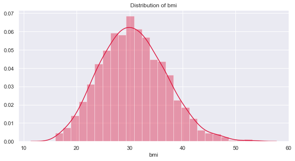

```python
plt.figure(figsize = (10,5)) #size of figure is adjusted in inches
plt.title('Distribution of bmi') #title of plot
sns.distplot(df['bmi'],color='crimson') #Distance plot of 'bmi'
```

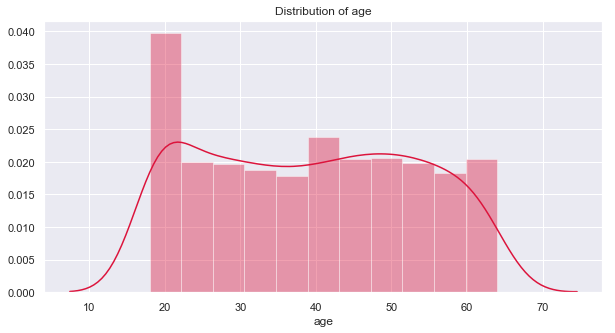

```python
plt.figure(figsize = (10,5)) #size of figure is adjusted in inches
plt.title('Distribution of age') #title of plot
sns.distplot(df['age'], color='crimson')#Distance plot of 'age'
```

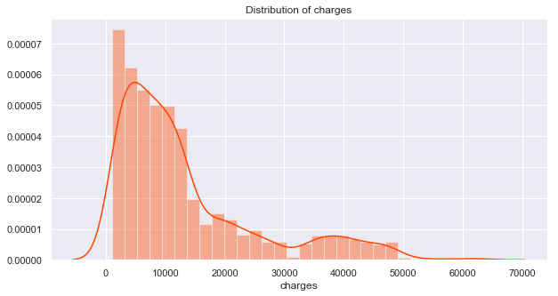

```python
plt.figure(figsize = (10,5))#size of figure is adjusted in inches
plt.title('Distribution of charges') #title of plot
sns.distplot(df['charges'],color='orangered') #Distance plot of 'charges'
```

#### The distribution of charges is right skewed.

#### f. Measure of skewness of ‘bmi’, ‘age’ and ‘charges’ columns

```python
print('\033[1m''Skewness of BMI column:',df['bmi'].skew()) #.skew() returns measure of skewness
```

```
Skewness of BMI column: 0.2840471105987448
```

```python
print('\033[1m''Skewness of age column:',df['age'].skew())
```

```
Skewness of age column: 0.05567251565299186
```

```python
print('\033[1m''Skewness of charges column:',df['charges'].skew())
```

```
Skewness of charges column: 1.5158796580240388
```

#### g. Checking the presence of outliers in ‘bmi’, ‘age’ and ‘charges columns

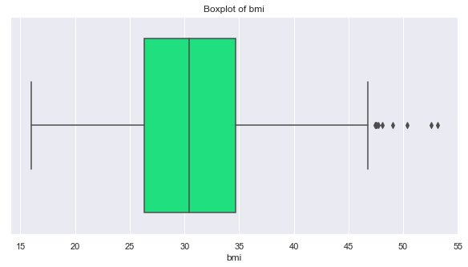

```python
plt.figure(figsize = (10,5)) #size of figure is adjusted in inches
plt.title('Boxplot of bmi') #title of plot
sns.boxplot(x='bmi',data=df,color='springgreen') #Box plot of 'bmi' for finding outliers plotted using seaborn
```

#### The presence of outliers can be seen in above boxplot of 'bmi'

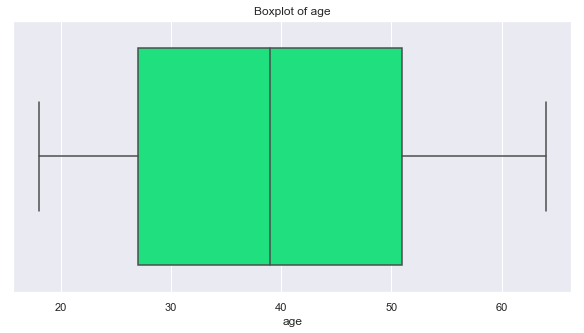

```python
plt.figure(figsize = (10,5)) #size of figure is adjusted in inches
plt.title('Boxplot of age') #title of plot
sns.boxplot(x='age',data=df,color='springgreen') #Box plot of 'age' for finding outliers
```

#### The absence of outliers can be seen in above boxplot of 'age'

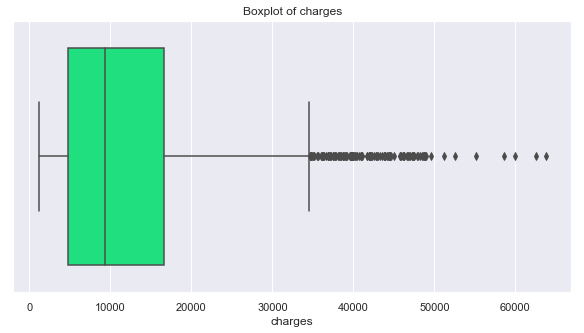

```python
plt.figure(figsize = (10,5))  #size of figure is adjusted in inches
plt.title('Boxplot of charges') #title of plot
sns.boxplot(x='charges',data=df,color='springgreen') #Box plot of 'charges' for finding outliers
```

#### The presence of outliers can be seen in above boxplot of 'charges'

#### Boxplots for 'bmi' and 'chrages' show the presence of outliers,whereas there are no outliers in 'age'

#### h. Distribution of categorical columns (include children)

```python
df['sex'].value_counts().to_frame('Total') #categorywise total count is calculated using .value_counts()
```

|  | Total |
| --- | --- |
| male | 676 |
| female | 662 |

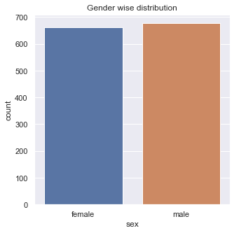

```python
plt.figure(figsize = (5,5))   #size of figure is adjusted in inches
plt.title('Gender wise distribution')  #title of plot
sns.countplot(x=df['sex'],data=df) #Countplot of 'sex'
```

```python
df['region'].value_counts().to_frame('Region') #categorywise total count is calculated using .value_counts()
```

|  | Region |
| --- | --- |
| southeast | 364 |
| southwest | 325 |
| northwest | 325 |
| northeast | 324 |

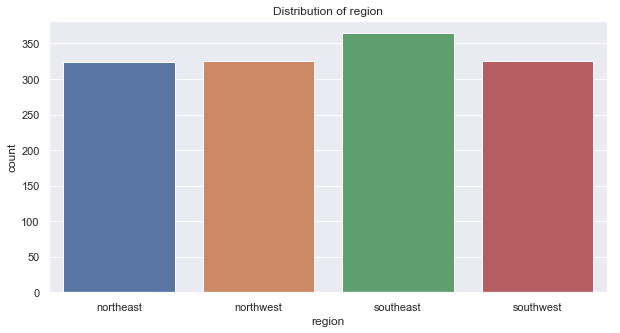

```python
plt.figure(figsize = (10,5)) #size of figure is adjusted in inches
plt.title('Distribution of region')  #title of plot
sns.countplot(x=df['region'],data=df) #Countplot of 'Region'
```

```python
df['children'].value_counts().to_frame('Total number of children') #categorywise total count is calculated using .value_counts()
```

|  | Total number of children |
| --- | --- |
| 0 | 574 |
| 1 | 324 |
| 2 | 240 |
| 3 | 157 |
| 4 | 25 |
| 5 | 18 |

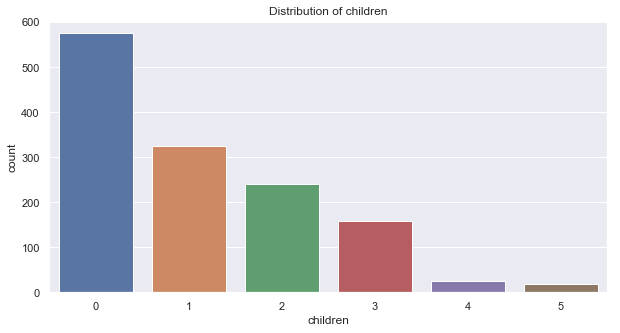

```python
plt.figure(figsize=(10,5)) #size of figure is adjusted in inches
plt.title('Distribution of children')  #title of plot
sns.countplot(x=df['children'],data=df) #Countplot of 'Children'
```

```python
df['smoker'].value_counts().to_frame('Total Smokers') #categorywise total count is calculated using .value_counts()
```

|  | Total Smokers |
| --- | --- |
| no | 1064 |
| yes | 274 |

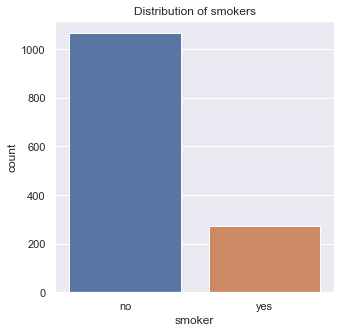

```python
plt.figure(figsize=(5,5)) #size of figure is adjusted in inches
plt.title('Distribution of smokers')  #title of plot
sns.countplot(x=df['smoker'],data=df) #Countplot of 'Smokers'
```

#### i. Pair plot that includes all the columns of the data frame

#### processing 'sex','smoker' columns and replacing yes,no values with 1 and 0 for processing and including all columns in pairplot as pairplot cannot process string values like 'yes'/'no'.

```python
df_2 = df.copy() #making a copy of dataframe 'df'
encoder = LabelEncoder() #creating object of LabelEncoder
df_2['sex'] = encoder.fit_transform(df_2['sex']).astype(int) #encoding 'sex' column and assigning 0 and 1 values
df_2['smoker'] = encoder.fit_transform(df_2['smoker']).astype(int) #encoding 'smoker' column and assigning 0 and 1 values
df_2.head() #displaying head of encoded dataframe
#The LabelEncoder has taken 0 for female and 1 for male in the 'sex' column
#The LabelEncoder has taken 1 for yes and 0 for no in the'smoker' column
```

|  | age | sex | bmi | children | smoker | region | charges |
| --- | --- | --- | --- | --- | --- | --- | --- |
| 0 | 19 | 0 | 27.900 | 0 | 1 | southwest | 16884.92400 |
| 1 | 18 | 1 | 33.770 | 1 | 0 | southeast | 1725.55230 |
| 2 | 28 | 1 | 33.000 | 3 | 0 | southeast | 4449.46200 |
| 3 | 33 | 1 | 22.705 | 0 | 0 | northwest | 21984.47061 |
| 4 | 32 | 1 | 28.880 | 0 | 0 | northwest | 3866.85520 |

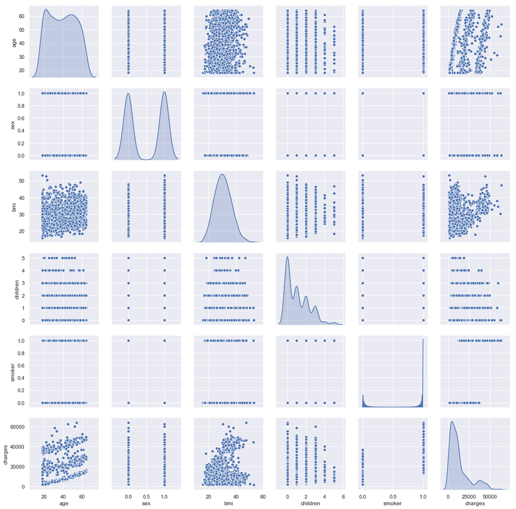

```python
sns.pairplot(df_2,diag_kind='kde') # pairplot of dataframe with Kernel Density Estimation and scatter kind
```

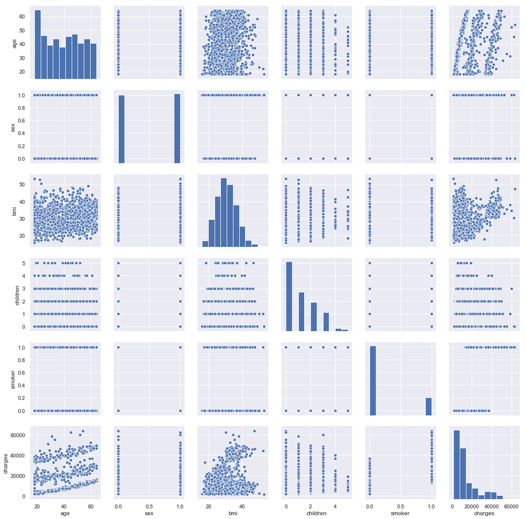

```python
sns.pairplot(df_2) # pairplot of dataframe without Kernel Density Estimation and scatter kind
```

### 3D Surface plot of age,bmi and charges

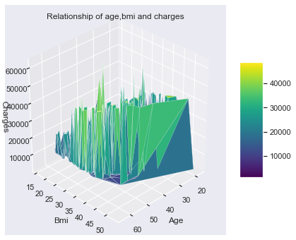

```python
fig = plt.figure(figsize=(7,6))
ax = fig.gca(projection='3d')
surf=ax.plot_trisurf(df['age'], df['bmi'], df['charges'], cmap=plt.cm.viridis, linewidth=0.2)
fig.colorbar( surf, shrink=0.5, aspect=5)
plt.title('Relationship of age,bmi and charges')
ax.set_xlabel('Age')
ax.set_ylabel('Bmi')
ax.set_zlabel('Charges')
ax.view_init(30, 45)
plt.show()
```

### 3D Scatter plot of age,bmi and charges

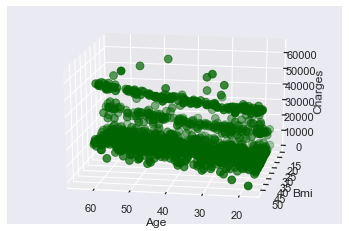

```python
fig = plt.figure()
ax = fig.add_subplot(111, projection='3d')
ax.scatter(df['age'], df['bmi'], df['charges'], c='darkgreen', s=60)
ax.set_xlabel('Age')
ax.set_ylabel('Bmi')
ax.set_zlabel('Charges')
ax.view_init(20, 100)
plt.show()
```

## 4. Answer the following questions with statistical evidence

#### a. Do charges of people who smoke differ significantly from the people who don't?

```python
df.groupby('smoker')['charges'].describe() #.groupby is uesd to split dataframe by 'smokers' and corresponding 'charges'
                                           #.describe() returns five point summary
```

| smoker | count | mean | std | min | 25% | 50% | 75% | max |
| --- | --- | --- | --- | --- | --- | --- | --- | --- |
| no | 1064.0 | 8434.268298 | 5993.781819 | 1121.8739 | 3986.438700 | 7345.40530 | 11362.887050 | 36910.60803 |
| yes | 274.0 | 32050.231832 | 11541.547176 | 12829.4551 | 20826.244213 | 34456.34845 | 41019.207275 | 63770.42801 |

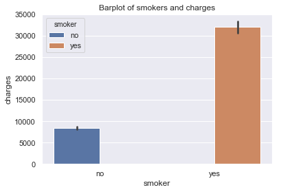

```python
plt.title('Barplot of smokers and charges')  #title of plot
sns.barplot(x = 'smoker', y = 'charges', hue = 'smoker', data = df ) #barplot of 'smokers' and 'charges'
```

#### Above barplot shows that charges for smokers are higher than non-smokers

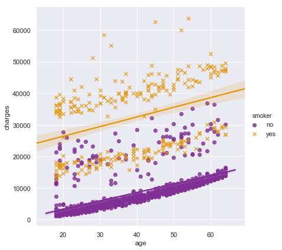

```python
sns.lmplot(x = 'age', y = 'charges', hue = 'smoker', data = df, palette='CMRmap', markers = ["o", "x"], height=6)
#lmplot of 'age' and 'charges' with categorization as hue='smoker'
```

#### It can be observed in above plot that charges for smokers are higher than non-smokers

## Statistics Test:

#### Ho : Charges of people who smoke do not differ from the people who don't

#### Ha : Charges of people who smoke differ significantly from the people who don't

## Using T-Test:

```python
t_statistics, p_value = ttest_ind(df_2['charges'],df_2['smoker']) #using ttest_ind() and passed 'charges' and 'smoker' columns
print('T-Statistic value:',t_statistics, '\nP-Value:', p_value)  #print t-value and p-values

if p_value > 0.05: # significance level is 0.05
    print('\033[1m''Fail to reject Null Hypothesis i.e. charges do not differ for smokers and non-smokers')
else:
    print('\033[1m''Reject Null Hypothesis i.e. charges differ for smokers and non-smokers')
```

```
T-Statistic value: 40.08312294525875
P-Value: 1.5354226097474645e-275
Reject Null Hypothesis i.e. charges differ for smokers and non-smokers
```

#### b. Does bmi of males differ significantly from that of females?

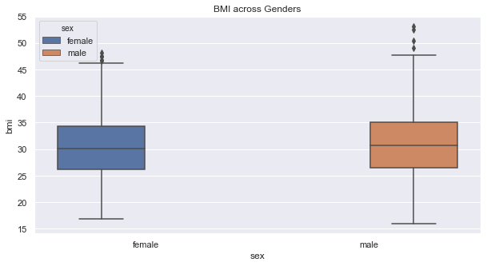

```python
plt.figure(figsize=(10,5)) #size of figure is adjusted in inches
plt.title('BMI across Genders') #title of plot
sns.boxplot(x='sex', y='bmi', hue='sex', data=df) #boxplot of 'sex' and 'bmi' columns with hue='sex'
```

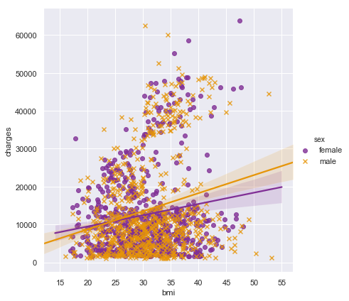

```python
sns.lmplot(x='bmi', y='charges', hue='sex', data=df, markers=['o','x'], height=6, palette='CMRmap')
#lmplot of 'bmi' and 'charges' with categorization as hue='sex'
```

#### Above plot shows charges increase as BMI increases

## Statistics test

#### Ho : bmi of males is not significantly higher from that of females

#### Ha : bmi of males is significantly higher from that of females

## Using T-test:

```python
t_statistics, p_value = ttest_ind(df_2['bmi'],df_2['sex']) #using ttest_ind() and passed 'charges' and 'smoker' columns
print('T-Statistic value:',t_statistics, '\nP-Value:', p_value) #print t-value and p-values

if p_value > 0.05: # significance level is 0.05
    print('\033[1m''Fail to reject Null Hypothesis i.e. bmi of males does not differ significantly from that of females')
else:
    print('\033[1m''Reject Null Hypothesis i.e.  bmi of male is significantly higher from that of females')
```

```
T-Statistic value: 180.29197723326152
P-Value: 0.0
Reject Null Hypothesis i.e.  bmi of male is significantly higher from that of females
```

#### c. Is the proportion of smokers significantly different in different genders?

```python
smoker_list = df['smoker'].groupby(df['sex']).value_counts().to_frame(name = 'Number of Smokers')
                                            #categorzation of 'male'/'female' and 'smoker'/'non-smoker'
smoker_list
```

| sex | smoker | Number of Smokers |
| --- | --- | --- |
| female | no | 547 |
|  | yes | 115 |
| male | no | 517 |
|  | yes | 159 |

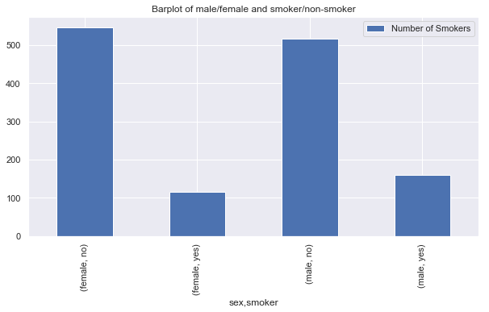

```python
smoker_list.plot(kind='bar',figsize=(10,5),title='Barplot of male/female and smoker/non-smoker')
#barplot of male/female and smoker/non-smoker
```

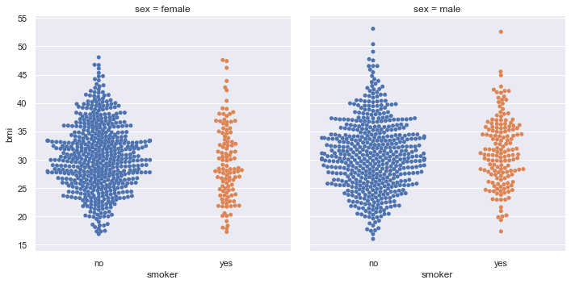

```python
sns.catplot(x='smoker',y='bmi',hue='smoker',data=df,col='sex',kind='swarm')
#swarmp plot of 'smoker' and 'bmi' with hue='smoker' and categorized by col='sex'
```

#### There are two genders 'male' and 'female' respectively, based on this the hypothesis can be formed as below:

- 'sex' and 'smoker' are two categorical variables
- We want to see if the proportion of smokers in both gender different
- 159 male smoke out of 676
- 115 females smoke out of 662
- Percentage of male smokers is higher than female

#### Ho = The proportion of smokers are equal in both genders

#### Ha = The two proportion of smokers are not equal in both genders

## Using z-test:

```python
female_smokers = df[df['sex'] == 'female'].smoker.value_counts()[1]  # number of female smokers
male_smokers = df[df['sex'] == 'male'].smoker.value_counts()[1] # number of male smokers
n_females = df.sex.value_counts()[1] # number of females in the data
n_males = df.sex.value_counts()[0] #number of males in the data
```

```python
print([female_smokers, male_smokers] , [n_females, n_males])
print('\033[1m'f' Proportion of smokers in females, males = {round(115/662,2)}%, {round(159/676,2)}% respectively')
```

```
[115, 159] [676, 662]
 Proportion of smokers in females, males = 0.17%, 0.24% respectively
```

#### The proportions are different but are they statistically significant?

```python
stat, pval = proportions_ztest([female_smokers, male_smokers] , [n_females, n_males]) #using ztest for proportion

if pval < 0.05:
    print('\033[1m'f'With a p-value of {round(pval,4)} the difference is significant. Reject Null hypothesis i.e. Proportion of smokers across genders is different')
else:
    print('\033[1m'f'With a p-value of {round(pval,4)} the difference is not significant. Fail to reject Null hypothesis i.e. Proportion of smokers across genders is similar')
```

```
With a p-value of 0.0015 the difference is significant. Reject Null hypothesis i.e. Proportion of smokers across genders is different
```

## Using Chi Square Test:

```python
smoking_cross = pd.crosstab(df['smoker'],df['sex']) #creating a crosstable
smoking_cross
```

| sex smoker | female | male |
| --- | --- | --- |
| no | 547 | 517 |
| yes | 115 | 159 |

```python
chi2_stats, p_value, dof, table = chi2_contingency(smoking_cross) #using chi-square test method
print('\033[1m''Chi2 Stastics:','%1.2f'% chi2_stats) #printing values
print('\033[1m''\nDegree of freedom:','%1.2f'% dof)
print('\033[1m''\nP-Value:','%1.2f'% p_value)
print('\033[1m''\nContingency table:\n', table)

if p_value > 0.05:
    print('\033[1m''\nFail to reject Null hypothesis i.e. Proportion of smokers across genders is similar')
else:
    print('\n''\033[1m''Reject Null hypothesis i.e. Proportion of smokers across genders is different')
```

```
Chi2 Stastics: 7.39

Degree of freedom: 1.00

P-Value: 0.01

Contingency table:
 [[526.43348281 537.56651719]
 [135.56651719 138.43348281]]

Reject Null hypothesis i.e. Proportion of smokers across genders is different
```

#### d. Is the distribution of bmi across women with no children, one child and two children, the same ?

```python
female_child = df[df.loc[:,'sex']=='female'] #picking only records of female
female_child
```

|  | age | sex | bmi | children | smoker | region | charges |
| --- | --- | --- | --- | --- | --- | --- | --- |
| 0 | 19 | female | 27.900 | 0 | yes | southwest | 16884.92400 |
| 5 | 31 | female | 25.740 | 0 | no | southeast | 3756.62160 |
| 6 | 46 | female | 33.440 | 1 | no | southeast | 8240.58960 |
| 7 | 37 | female | 27.740 | 3 | no | northwest | 7281.50560 |
| 9 | 60 | female | 25.840 | 0 | no | northwest | 28923.13692 |
| 11 | 62 | female | 26.290 | 0 | yes | southeast | 27808.72510 |
| 13 | 56 | female | 39.820 | 0 | no | southeast | 11090.71780 |
| 16 | 52 | female | 30.780 | 1 | no | northeast | 10797.33620 |
| 20 | 60 | female | 36.005 | 0 | no | northeast | 13228.84695 |
| 21 | 30 | female | 32.400 | 1 | no | southwest | 4149.73600 |
| 23 | 34 | female | 31.920 | 1 | yes | northeast | 37701.87680 |
| 25 | 59 | female | 27.720 | 3 | no | southeast | 14001.13380 |
| 26 | 63 | female | 23.085 | 0 | no | northeast | 14451.83515 |
| 27 | 55 | female | 32.775 | 2 | no | northwest | 12268.63225 |
| 31 | 18 | female | 26.315 | 0 | no | northeast | 2198.18985 |
| 32 | 19 | female | 28.600 | 5 | no | southwest | 4687.79700 |
| 36 | 62 | female | 32.965 | 3 | no | northwest | 15612.19335 |
| 40 | 24 | female | 26.600 | 0 | no | northeast | 3046.06200 |
| 41 | 31 | female | 36.630 | 2 | no | southeast | 4949.75870 |
| 43 | 37 | female | 30.800 | 2 | no | southeast | 6313.75900 |
| 46 | 18 | female | 38.665 | 2 | no | northeast | 3393.35635 |
| 47 | 28 | female | 34.770 | 0 | no | northwest | 3556.92230 |
| 48 | 60 | female | 24.530 | 0 | no | southeast | 12629.89670 |
| 50 | 18 | female | 35.625 | 0 | no | northeast | 2211.13075 |
| 51 | 21 | female | 33.630 | 2 | no | northwest | 3579.82870 |
| 54 | 40 | female | 28.690 | 3 | no | northwest | 8059.67910 |
| 56 | 58 | female | 31.825 | 2 | no | northeast | 13607.36875 |
| 58 | 53 | female | 22.880 | 1 | yes | southeast | 23244.79020 |
| 59 | 34 | female | 37.335 | 2 | no | northwest | 5989.52365 |
| 63 | 28 | female | 25.935 | 1 | no | northwest | 4133.64165 |
| ... | ... | ... | ... | ... | ... | ... | ... |
| 1277 | 32 | female | 29.735 | 0 | no | northwest | 4357.04365 |
| 1279 | 25 | female | 26.790 | 2 | no | northwest | 4189.11310 |
| 1280 | 48 | female | 33.330 | 0 | no | southeast | 8283.68070 |
| 1281 | 47 | female | 27.645 | 2 | yes | northwest | 24535.69855 |
| 1282 | 18 | female | 21.660 | 0 | yes | northeast | 14283.45940 |
| 1285 | 47 | female | 24.320 | 0 | no | northeast | 8534.67180 |
| 1286 | 28 | female | 17.290 | 0 | no | northeast | 3732.62510 |
| 1287 | 36 | female | 25.900 | 1 | no | southwest | 5472.44900 |
| 1290 | 38 | female | 19.950 | 2 | no | northeast | 7133.90250 |
| 1297 | 28 | female | 26.510 | 2 | no | southeast | 4340.44090 |
| 1299 | 19 | female | 25.745 | 1 | no | northwest | 2710.82855 |
| 1302 | 25 | female | 20.800 | 1 | no | southwest | 3208.78700 |
| 1305 | 24 | female | 27.720 | 0 | no | southeast | 2464.61880 |
| 1306 | 29 | female | 21.850 | 0 | yes | northeast | 16115.30450 |
| 1308 | 25 | female | 30.200 | 0 | yes | southwest | 33900.65300 |
| 1311 | 33 | female | 26.695 | 0 | no | northwest | 4571.41305 |
| 1313 | 19 | female | 34.700 | 2 | yes | southwest | 36397.57600 |
| 1314 | 30 | female | 23.655 | 3 | yes | northwest | 18765.87545 |
| 1316 | 19 | female | 20.600 | 0 | no | southwest | 1731.67700 |
| 1319 | 39 | female | 26.315 | 2 | no | northwest | 7201.70085 |
| 1323 | 42 | female | 40.370 | 2 | yes | southeast | 43896.37630 |
| 1326 | 42 | female | 32.870 | 0 | no | northeast | 7050.02130 |
| 1328 | 23 | female | 24.225 | 2 | no | northeast | 22395.74424 |
| 1330 | 57 | female | 25.740 | 2 | no | southeast | 12629.16560 |
| 1331 | 23 | female | 33.400 | 0 | no | southwest | 10795.93733 |
| 1332 | 52 | female | 44.700 | 3 | no | southwest | 11411.68500 |
| 1334 | 18 | female | 31.920 | 0 | no | northeast | 2205.98080 |
| 1335 | 18 | female | 36.850 | 0 | no | southeast | 1629.83350 |
| 1336 | 21 | female | 25.800 | 0 | no | southwest | 2007.94500 |
| 1337 | 61 | female | 29.070 | 0 | yes | northwest | 29141.36030 |

662 rows × 7 columns

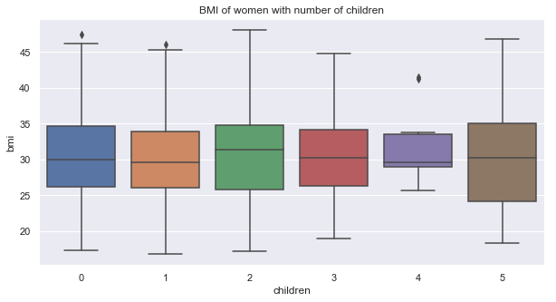

```python
plt.figure(figsize=(10,5))#size of figure is adjusted in inches
plt.title('BMI of women with number of children') #title of plot
sns.boxplot(x='children',y='bmi',data = female_child) #boxplot of number of children and bmi of women
```

#### It can be stated that there is no significant difference in the means of bmi of women with different number of children from above box plot

## Statistical Test:

#### Ho = Number of children has no effect on BMI of women

#### Ha = Number of children has effect on BMI of women

```python
formula = 'bmi ~ C(children)' #used to check is there any difference in bmi because of children
                              #C(children) indicates that 'children' is a categorical variable
model = ols(formula, df).fit() #ordinary least squares method and checks according to formula

aov_table = sm.stats.anova_lm(model) #analysis of variance method
aov_table #analsis of variacne table
```

|  | df | sum_sq | mean_sq | F | PR(>F) |
| --- | --- | --- | --- | --- | --- |
| C(children) | 5.0 | 65.112017 | 13.022403 | 0.349327 | 0.882868 |
| Residual | 1332.0 | 49655.088370 | 37.278595 | NaN | NaN |

```python
mc_table = MultiComparison(df['bmi'], df['children']) # Tests for multiple comparisons of bmi and children
result = mc_table.tukeyhsd() # Tukey’s range test to compare means of all pairs of bmi and children
print(result) # prints result table

print('Unique categories present in table:',mc_table.groupsunique) #prints multicomparision groups

tukey_res = mc_table.tukeyhsd()
p_values = psturng(np.abs(tukey_res.meandiffs / tukey_res.std_pairs), len(tukey_res.groupsunique), tukey_res.df_total)
print("p values:", p_values)
```

```
Multiple Comparison of Means - Tukey HSD,FWER=0.05
============================================
group1 group2 meandiff  lower  upper  reject
--------------------------------------------
  0      1     0.0729  -1.1379 1.2836 False
  0      2     0.4278  -0.9116 1.7672 False
  0      3     0.134   -1.4353 1.7034 False
  0      4     0.8409  -2.7191 4.4009 False
  0      5    -0.9453  -5.1162 3.2256 False
  1      2     0.355    -1.129 1.8389 False
  1      3     0.0612  -1.6332 1.7556 False
  1      4     0.7681  -2.8488 4.3849 False
  1      5    -1.0181  -5.2377 3.2014 False
  2      3    -0.2938  -2.0823 1.4948 False
  2      4     0.4131  -3.2488 4.075  False
  2      5    -1.3731  -5.6313 2.8851 False
  3      4     0.7069  -3.0452 4.459  False
  3      5    -1.0793  -5.4154 3.2567 False
  4      5    -1.7862  -7.1725 3.6001 False
--------------------------------------------
Unique categories present in table: [0 1 2 3 4 5]
p values: [0.9 0.9 0.9 0.9 0.9 0.9 0.9 0.9 0.9 0.9 0.9 0.9 0.9 0.9 0.9]
```